# Practical Machine Learning Course Project

Anuj Parashar

2/13/2019

## Predicting Personal Activity Effectiveness

### Objective

The objective of this project is to predict the manner (“classe” variable) in which a group of people did physical exercise. We are going to analyze the “Weight Lifting Exercise” dataset that comes from this source: http://web.archive.org/web/20161224072740/http:/groupware.les.inf.puc-rio.br/har.

### Steps Involved

For this analysis, the following steps would be followed:

1. Loading the data
2. Cleaning the data
3. Features Selection
4. Creating testing and training sets
5. Configuring parallel processing
6. Adding cross-validation
7. Train the Model
8. Analyzing the Model
9. Making predictions on test-set
10. Calculating out-of-sample errors
11. Quiz Result

We will be discussing the design consideration and assumptions as we go along. So, let’s get started.

#### 1. **Loading the data**

```r
# Loading Libraries
library(caret)
library(parallel)
library(doParallel)

# Loading the files
rawData   <- read.csv(file = "/Users/promisinganuj/Downloads/pml-training.csv", na.strings = c("#DIV/0!", "NA"))
finalTest <- read.csv(file = "/Users/promisinganuj/Downloads/pml-testing.csv" , na.strings = c("#DIV/0!", "NA"))
```

We are going to use “caret” package for creating the model. The “parallel” package is used to enable parallelism while training the model. This is helpful as this dataset has lot of predictor variables as we are going to see next.

```r
rbind(train = dim(rawData), test = dim(finalTest))
```

```
       [,1] [,2]
train 19622  160
test     20  160
```

As shown above, there are 159 potential predictor variables (+1 predited variable).

#### 2. **Cleaning the data**

```r
rawData   <- rawData  [lapply(rawData  , function(x) sum(is.na(x)) / length(x)) < 0.05]
finalTest <- finalTest[lapply(finalTest, function(x) sum(is.na(x)) / length(x)) < 0.05]
rbind(train = dim(rawData), test = dim(finalTest))
```

```
       [,1] [,2]
train 19622   60
test     20   60
```

#### 3. **Features Selection**

Most of the columns left are actual measurement values but there are certain columns that can be removed especially the timestamps, id and username. Let’s look at these variables

```r
head(rawData[,1:7], n = 2)
```

```
  X user_name raw_timestamp_part_1 raw_timestamp_part_2   cvtd_timestamp
1 1  carlitos           1323084231               788290 05/12/2011 11:23
2 2  carlitos           1323084231               808298 05/12/2011 11:23
  new_window num_window
1         no         11
2         no         11
```

Let’s also look at the “near zero variabiliy”.

```r
nsv <- nearZeroVar(rawData, saveMetrics = TRUE)
head(nsv, n = 7)
```

```
                     freqRatio percentUnique zeroVar   nzv
X                     1.000000  100.00000000   FALSE FALSE
user_name             1.100679    0.03057792   FALSE FALSE
raw_timestamp_part_1  1.000000    4.26562022   FALSE FALSE
raw_timestamp_part_2  1.000000   85.53154622   FALSE FALSE
cvtd_timestamp        1.000668    0.10192641   FALSE FALSE
new_window           47.330049    0.01019264   FALSE  TRUE
num_window            1.000000    4.37264295   FALSE FALSE
```

```r
dropCol   <- c("X","user_name","raw_timestamp_part_1","raw_timestamp_part_2","cvtd_timestamp","new_window")
rawData   <- rawData[!names(rawData) %in% dropCol]
finalTest <- finalTest[!names(finalTest) %in% dropCol]
dim(rawData)
```

```
[1] 19622    54
```

Lets verify that both the datasets are still structurally same

```r
all(names(rawData[,-54]) == names(finalTest[,-54]))
```

```
[1] TRUE
```

#### 4. **Creating training and test set**

```r
set.seed(12465)
inTrain <- createDataPartition(rawData$classe, p = 0.7, list = FALSE)
training <- rawData[inTrain,]
testing  <- rawData[-inTrain,]
```

Here we are doing a 70/30 split between training and test dataset.

#### 5. **Configuring parallel processing**

As there are lots of predictors, enabling parallel processing in this case will certainly help in training the model fast.

```r
# Creating cluster based on the available CPU cores. It's conventional to leave 1 core for OS
cluster <- makeCluster(detectCores() - 1)
registerDoParallel(cluster)
```

#### 6. **Adding Cross Validation**

Peforming cross-validation is almost always a good idea to help reducing the in and out of sample error. Here, we are going to use K-fold validation with number = 5.

```r
train.control <- trainControl(method = "cv", number = 5, allowParallel = TRUE)
```

Notice that we have set parameter “allowParallel” to enable parallel processing based on the configuration we just added.

#### 7. **Train the Model**

Everything set, now we are ready to train our model. We are going to use “random forest” with caret::train for this.

```r
mf <- train(classe ~., data = training, method = "rf", trControl = train.control)
stopCluster(cluster)   # Stopping the parallel processing
registerDoSEQ()
mf                     # Printing the model
```

```
Random Forest

13737 samples
   53 predictor
    5 classes: 'A', 'B', 'C', 'D', 'E'

No pre-processing
Resampling: Cross-Validated (5 fold)
Summary of sample sizes: 10989, 10990, 10990, 10991, 10988
Resampling results across tuning parameters:

  mtry  Accuracy   Kappa
   2    0.9937399  0.9920812
  27    0.9966516  0.9957647
  53    0.9909015  0.9884893

Accuracy was used to select the optimal model using the largest value.
The final value used for the model was mtry = 27.
```

#### 9. **Making predictions on test-set**

Now, let’s apply the model on test dataset.

```r
pred <- predict(mf, testing)
confusionMatrix(pred, testing$classe)
```

```
Confusion Matrix and Statistics

          Reference
Prediction    A    B    C    D    E
         A 1674    5    0    0    0
         B    0 1133    0    0    0
         C    0    1 1023    9    0
         D    0    0    3  954    5
         E    0    0    0    1 1077

Overall Statistics

               Accuracy : 0.9959
                 95% CI : (0.9939, 0.9974)
    No Information Rate : 0.2845
    P-Value [Acc > NIR] : < 2.2e-16

                  Kappa : 0.9948
 Mcnemar's Test P-Value : NA

Statistics by Class:

                     Class: A Class: B Class: C Class: D Class: E
Sensitivity            1.0000   0.9947   0.9971   0.9896   0.9954
Specificity            0.9988   1.0000   0.9979   0.9984   0.9998
Pos Pred Value         0.9970   1.0000   0.9903   0.9917   0.9991
Neg Pred Value         1.0000   0.9987   0.9994   0.9980   0.9990
Prevalence             0.2845   0.1935   0.1743   0.1638   0.1839
Detection Rate         0.2845   0.1925   0.1738   0.1621   0.1830
Detection Prevalence   0.2853   0.1925   0.1755   0.1635   0.1832
Balanced Accuracy      0.9994   0.9974   0.9975   0.9940   0.9976
```

The model, when applied to test-set, has an accuracy of 99.59% which is pretty close to training model accuracy. That means it’s a pretty well tuned. Let’s check the variable importance chart which is quite useful in case we decide to further tune the model.

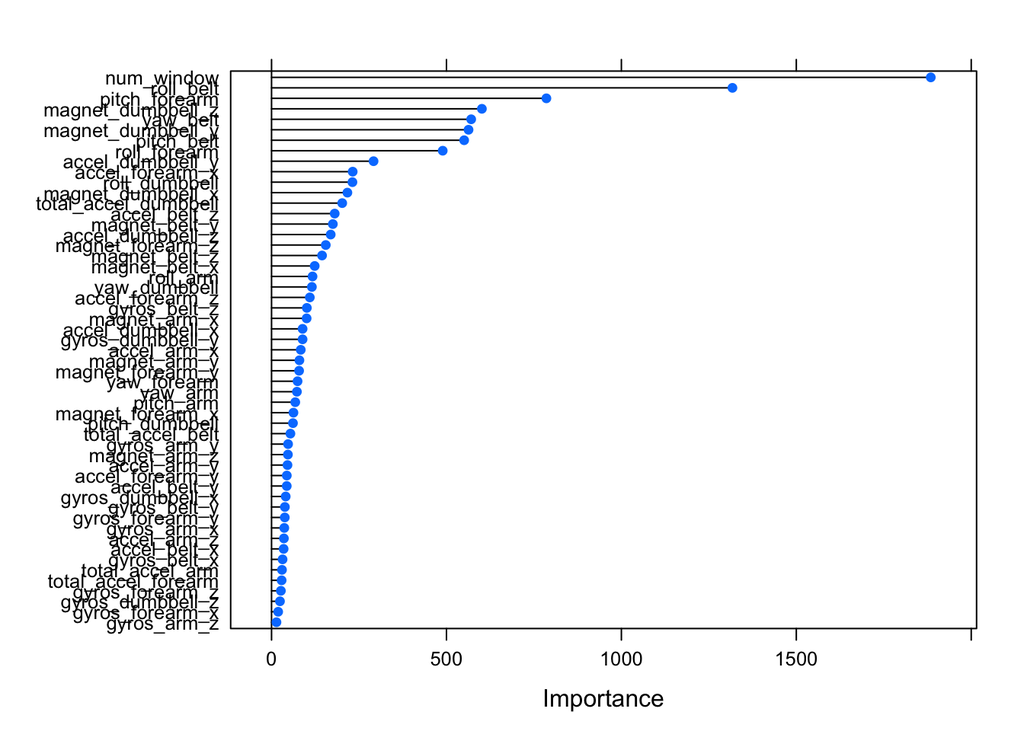

```r
plot(varImp(mf, scale = FALSE))
```

It’s evident from the graph that the variable “num_window” has the maximum importance amoung the selected variables.

#### 10. **Calculating out-of-sample error**

Another way to calculate the model “accuracy” is to manually calculate it as follows:

```r
outOfSampleAccuracy <- sum(pred == testing$classe) / length(pred)
outOfSampleError    <- 1 - outOfSampleAccuracy
print(paste("Out-of-Sample Error:", round(outOfSampleError * 100, 2), "%"))
```

```
[1] "Out-of-Sample Error: 0.41 %"
```

#### 11. **Quiz Result**

```r
predQuiz <- predict(mf, finalTest)
predQuiz
```

As per the honor code, the result is not published. But if you have come so far, you already know the solution.